# My Phone Usage Visual Story

STATS 220 Semester One 2025

Keeru Rangu

## Introduction

This story explores patterns in how I use my phone, based on observational data I collected using a Google Form. The data was logged across various contexts and moods throughout my daily life, helping me investigate how and why I reach for my phone.

## Mood Before Using the Phone

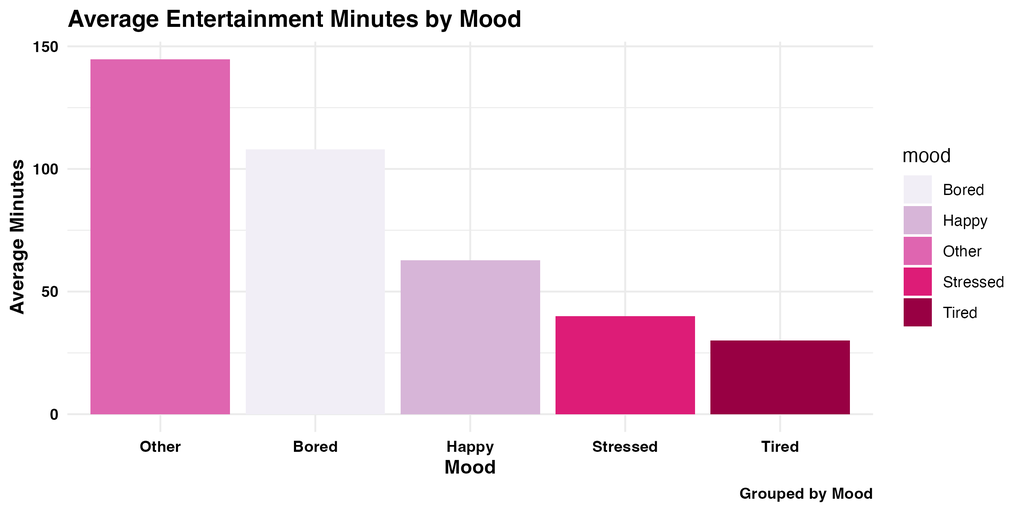

This bar plot shows the average number of entertainment minutes logged per mood (e.g., bored, stressed). It was grouped by both mood and weekday, using group_by() and summarised with mean(). We also used lubridate::wday() to extract the weekday from the timestamp, giving more temporal context.

To clean inconsistent text formatting, I used stringr::str_to_title() to capitalise mood responses like “bored” into “Bored”.

“Other” and “Bored” moods had the highest average entertainment times. This shows that when I’m unmotivated or disengaged, I’m more likely to spend longer on my phone for entertainment.

## Entertainment vs Total Use

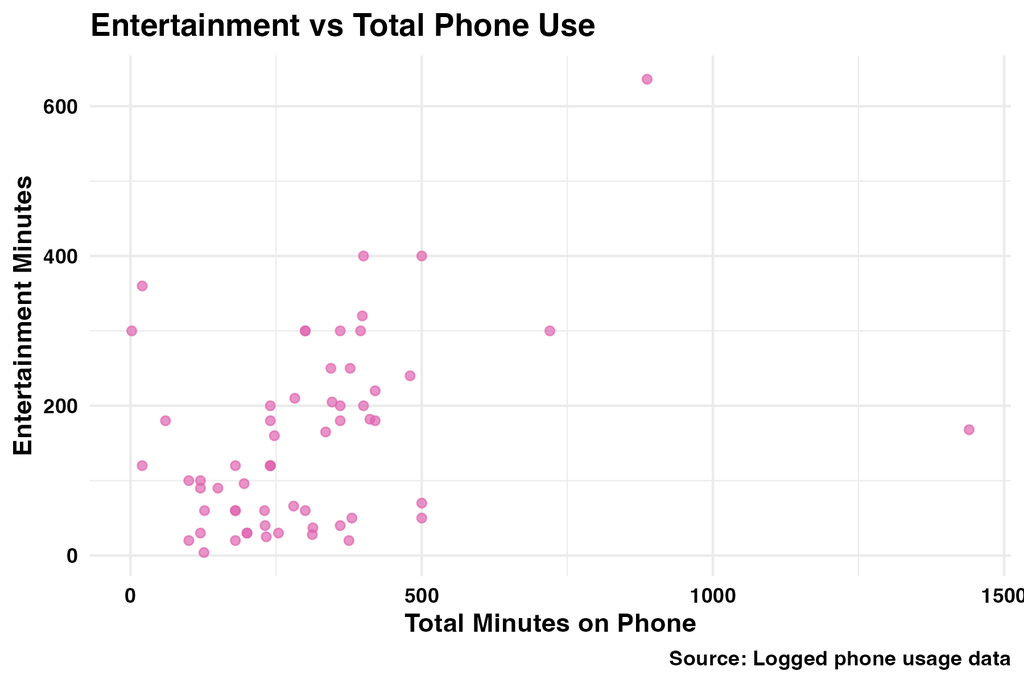

This scatter plot shows that as total phone use increases, entertainment use tends to increase as well. Most entries fall below 400 minutes for total mintues, with entertainment minutes commonly ranging between 100 and 300. A few outliers indicate very high total phone usage, suggesting occasional heavy-use days.

## Peak Phone Use Time

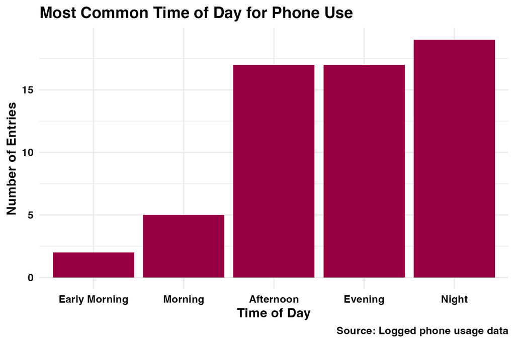

This bar chart shows the times of day when phone use was most frequent. Most entries were logged in the afternoon, evening, and night, indicating a clear preference for phone use later in the day. Fewer entries were recorded in the early morning and morning. This distribution reflects typical daily routines, where phone engagement increases after midday.

## Phone Use Duration by Mood

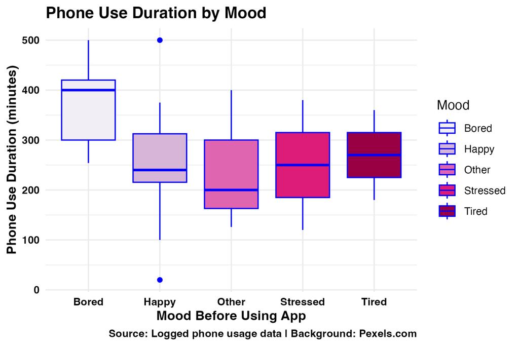

## Bonus Creative Visualisation

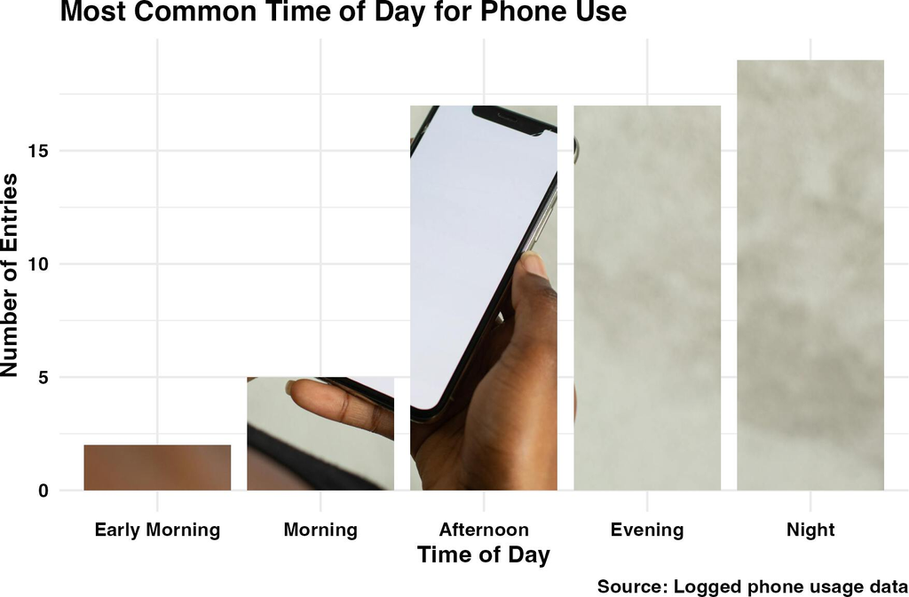

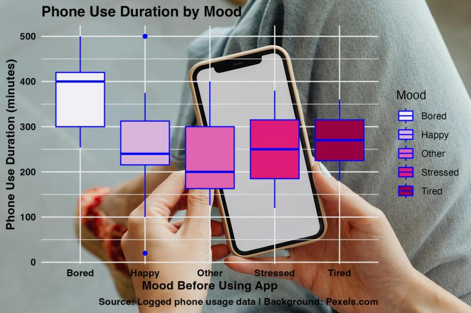

In two of my plots, I used creative enhancements to elevate storytelling:

creative_plot3.png: I used the {cuttingshapes} package to fill each bar of the “Most Common Time of Day for Phone Use” chart with a real-world image of someone using a phone. Each bar is filled with a portion of the photo, making the visual more immersive and clearly linking the theme of device use with the concept of daily routines.

creative_plot4.png: I used the {magick} package to overlay my box plot of phone use by mood onto a realistic background image of a person holding a phone. The vibrant colors of the plot stand out well against the image, and this visual metaphor reinforces how our moods affect our device engagement..

These enhancements not only made the visuals more engaging, but they also aligned thematically with the data story—making the connection between mood, time of day, and phone usage more relatable.

## Conclusion

It was interesting to see that although I rarely use my phone early in the morning, the time I do spend later in the day increases substantially. Visually exploring my data made it easier to identify when I tend to be more distracted and how mood drives my screen time.

## GitHub Link

You can view the HTML visual data story on GitHub **[here](https://keerur.github.io/stats220/visual_data_story.html).**

```r
library(tidyverse)
library(lubridate)
library(stringr)
library(magick)


install.packages("remotes")
remotes::install_github("annafergusson/cuttingshapes")
library(cuttingshapes)




logged_data <- read_csv("https://docs.google.com/spreadsheets/d/e/2PACX-1vSnGZftiMapz_Zg6q_MLISNyoJ3PQ2kFAnSDlLvuXmJQuxxTAMDmfvt9W-rILHm2Ez1NyIkQMsqTQZy/pub?output=csv")
my_colours <- c("#f1eef6", "#d7b5d8", "#df65b0", "#dd1c77", "#980043")



# Plot 1 - Avg entertainment by mood (grouped + summarised)
avg_entertainment <- logged_data %>%
  mutate(timestamp = mdy_hm(Timestamp),
         weekday = wday(timestamp, label = TRUE),
         entertainment = as.numeric(`How many minutes did you spend on entertainment (e.g., streaming, games, social media) on your phone today?`),
         mood = str_to_title(`What was your mood before using the app?`)) %>%
  filter(!is.na(mood)) %>%
  group_by(mood, weekday) %>%
  summarise(avg_ent = mean(entertainment, na.rm = TRUE)) %>%
  arrange(desc(avg_ent))


ggplot(avg_entertainment) +
  geom_col(aes(x = reorder(mood, -avg_ent), y = avg_ent, fill = mood)) +
  scale_fill_manual(values = my_colours) +
  labs(title = "Average Entertainment Minutes by Mood",
       x = "Mood", y = "Average Minutes",
       caption = "Grouped by Mood") +
  theme_minimal() +
  theme(
    axis.text = element_text(color = "black", face = "bold"),
    axis.title = element_text(color = "black", face = "bold"),
    plot.title = element_text(color = "black", face = "bold"),
    plot.caption = element_text(color = "black", face = "bold")
  )

ggsave("plot1.png", width = 8, height = 4)






# Plot 2 - Scatter plot of total vs entertainment use
logged_data <- logged_data %>%
  mutate(total_use = as.numeric(`How many minutes did you use your phone today?`),
         entertainment = as.numeric(`How many minutes did you spend on entertainment (e.g., streaming, games, social media) on your phone today?`))

ggplot(logged_data) +
  geom_point(aes(x = total_use, y = entertainment), color = my_colours[3], alpha = 0.7) +
  labs(title = "Entertainment vs Total Phone Use",
       x = "Total Minutes on Phone",
       y = "Entertainment Minutes",
       caption = "Source: Logged phone usage data") +
  theme_minimal() +
  theme(
    axis.text = element_text(color = "black", face = "bold"),
    axis.title = element_text(color = "black", face = "bold"),
    plot.title = element_text(color = "black", face = "bold"),
    plot.caption = element_text(color = "black", face = "bold")
  )

ggsave("plot2.png", width = 6, height = 4)






# Plot 3 - Frequency of peak phone use time by time-of-day category
logged_data <- logged_data %>%
  mutate(active_time = `At what time of day did you use your phone the most?`,
         time_of_day = case_when(
           active_time == 1 ~ "Early Morning",
           active_time == 2 ~ "Morning",
           active_time == 3 ~ "Afternoon",
           active_time == 4 ~ "Evening",
           active_time == 5 ~ "Night"
         ),
         time_of_day = factor(time_of_day,
                              levels = c("Early Morning", "Morning", "Afternoon", "Evening", "Night")))

ggplot(logged_data) +
  geom_bar(aes(x = time_of_day), fill = my_colours[5]) +
  labs(title = "Most Common Time of Day for Phone Use",
       x = "Time of Day",
       y = "Number of Entries",
       caption = "Source: Logged phone usage data") +
  theme_minimal() +
  theme(
    axis.text = element_text(color = "black", face = "bold"),
    axis.title = element_text(color = "black", face = "bold"),
    plot.title = element_text(color = "black", face = "bold"),
    plot.caption = element_text(color = "black", face = "bold")
  )

ggsave("plot3.png", width = 6, height = 4)



image_url <- "https://images.pexels.com/photos/9430875/pexels-photo-9430875.jpeg?auto=compress&cs=tinysrgb&w=1260&h=750&dpr=2"

creative_plot <- cut_shape(
  image = image_url,
  shape = "plot3.png",       # path to your saved plot image
  color = my_colours[5]
)

# Save the new creative image
image_write(creative_plot, "creative_plot3.png")

print(creative_plot)




# Plot 4
logged_data <- logged_data %>%
  mutate(
    mood = str_to_title(`What was your mood before using the app?`),
    phone_minutes = as.numeric(`How many minutes did you use your phone today?`)
  ) %>%
  filter(!is.na(mood))

ggplot(logged_data) +
  geom_boxplot(aes(x = mood, y = phone_minutes, fill = mood),
               colour = "blue",
               alpha = 1,
               na.rm = TRUE) +
  scale_fill_manual(values = my_colours) +
  labs(
    title = "Phone Use Duration by Mood",
    x = "Mood Before Using App",
    y = "Phone Use Duration (minutes)",
    fill = "Mood",
    caption = "Source: Logged phone usage data | Background: Pexels.com"
  ) +
  theme_minimal() +
  theme(
    axis.text = element_text(color = "black", face = "bold"),
    axis.title = element_text(color = "black", face = "bold"),
    plot.title = element_text(color = "black", face = "bold"),
    plot.caption = element_text(color = "black", face = "bold")
  )

ggsave("plot4.png", width = 6, height = 4)


# with extra creativity
plot_img <- image_read("plot4.png")
background_img <- image_read("https://images.pexels.com/photos/8947145/pexels-photo-8947145.jpeg?auto=compress&cs=tinysrgb&w=1260&h=750&dpr=2")

# Resize and combine them
plot_img <- image_resize(plot_img, "800x600")
background_img <- image_resize(background_img, "800x600")
combined_img <- image_composite(background_img, plot_img, offset = "+0+0")

# Preview and save the final image
print(combined_img)
image_write(combined_img, "creative_plot4.png")
```